# HUGEN 2072 Project 2

```r
chk
```

```
## $subfamilies.ident
##    family subfamily   individ
## 2    1341         1 200030290
## 3    1341         1 200099417
## 1    1341         1 200191449
## 5    1341         2 200015835
## 6    1341         2 200039107
## 4    1341         2 200122600
## 7    1362         1 200003297
## 8    1362         1 200169440
## 9    1362         1 200187448
## 12   1362         2 200018192
## 10   1362         2 200024383
## 11   1362         2 200118709
```

```r
#   subfamilies.ident
subf <- chk$subfamilies.ident
subf
```

```
##    family subfamily   individ
## 2    1341         1 200030290
## 3    1341         1 200099417
## 1    1341         1 200191449
## 5    1341         2 200015835
## 6    1341         2 200039107
## 4    1341         2 200122600
## 7    1362         1 200003297
## 8    1362         1 200169440
## 9    1362         1 200187448
## 12   1362         2 200018192
## 10   1362         2 200024383
## 11   1362         2 200118709
```

```r
table(subf$family)
```

```
##
## 1341 1362
##    6    6
```

```r
#   This identifies subfamilies (families where not everyone is linked into the
#   same pedigree as constructed by fathers'/mothers' IDs)

#   We should make these subfamilies into new families

#   Get the individuals from subfamily 2 from each family and add on "-2" their
#   family IDs
subf.ids <- subf$individ[subf$subfamily == 2]
newfam <- ped.complete$individ %in% subf.ids
ped.complete$family[newfam] <-
  paste0(ped.complete$family[newfam], "-2")

#   Now families 1341 and 1362 have been split into 2 trios (the new families
#   are 1341-2 and 1362-2)
table(ped.complete$family)
```

```
##
##     12   1334   1340   1341 1341-2   1344   1347   1362 1362-2   1408     28
##      3      3      3      3      3      3      3      3      3      3      3
##      4      5     58      9
##      3      3      3      3
```

```r
#   pedigreeCheck now returns NULL, meaning the pedigree now has no problems
pedigreeCheck(ped.complete)
```

```r
#   Now we can calculate the pairwise expected relatedness for all the subjects
#   in the completed pedigree

#   The function pedigreePairwiseRelatedness returns a list summarizing the
#   relationships
rels <- pedigreePairwiseRelatedness(ped.complete)

#   First, we can see that none of the parents are related by looking at
#   inbred.fam
length(rels$inbred.fam)
```

```
## [1] 0
```

```r
#   Next we extract relativeprs, a data frame summarizing the relationships
relprs <- rels$relativeprs

#   It contains relationship type (e.g., parent-offspring, unrelated, etc.) and
#   kinship coefficient for each pair within each family
relprs[1:5,]
```

```
##    Individ1  Individ2 relation kinship family
## 1 200191449 200030290       PO    0.25   1341
## 2 200191449 200099417        U    0.00   1341
## 3 200030290 200099417       PO    0.25   1341
## 4 200099636 200032162        U    0.00   1340
## 5 200099636 200076256       PO    0.25   1340
```

```r
table(relprs$relation)
```

```
##
## PO  U
## 30 15
```

```r
#   We see that our pedigree is relatively simple: 30 parent-offspring pairs
#   (PO) and 15 unrelated

#   (If we had a more complex pedigree structure, we would see more types of
#   relationships listed)

### Now we want to plot of the IBD coefficient estimates, color coded by the
### expected relationships we've just calculated

#   But first we need to merge together the expected and observed genetic
#   relationship data for all the pairs of scans

#   First, get all the scanIDs/subjectIDs from scanAnnot
samp <- pData(scanAnnot)[, c("scanID", "subjectID")]

#   Make sure the order matches that in the IBD object
samp <- samp[match(ibdobj$sample.id, samp$scanID), ]

#   Rename subjecID as Individ (like in the pedigree)
names(samp) <- c("scanID", "Individ")

#   Use snpgdsIBDSelection to find all pairs of samples with kinship coefficient
ibd <- snpgdsIBDSelection(ibdobj)

#   Merge in the subjectIDs that go with the scanIDs
ibd <- merge(ibd, samp, by.x = "ID1", by.y = "scanID")
ibd <-
  merge(
    ibd,
    samp,
    by.x = "ID2",
    by.y = "scanID",
    suffixes = c("1", "2")
  )

#   Create a pair-identifier variable to enable merging ibd with relprs (i.e.,
#   merge the observed and expected genetic relationship data)
ibd$ii <- pasteSorted(ibd$Individ1, ibd$Individ2)
relprs$ii <- pasteSorted(relprs$Individ1, relprs$Individ2)

#   Merge these together
ibd <- merge(ibd, relprs[, c("ii", "relation")], all.x = TRUE)

#   Rename the "relation" column (it refers to the expected relationship based
#   on the pedigree, so call it exp.rel)
names(ibd)[names(ibd) == "relation"] <- "exp.rel"

#   For pairs of samples from the same person, set exp.rel="Dup" (duplicate)
ibd$exp.rel[ibd$Individ1 == ibd$Individ2] <- "Dup"

#   For the remaining pairs with missing exp.rel, replace the missing value with "U" (unknown)
ibd$exp.rel[is.na(ibd$exp.rel)] <- "U"
table(ibd$exp.rel, useNA = "ifany")
```

```
##
##  Dup   PO    U
##   34   91 2801
```

```r
#   Use the ibdAssignRelatednessKing function to call the observed relationships
#   based on IBS0 and kinship values for each pair
ibd$obs.rel <- ibdAssignRelatednessKing(ibd$IBS0, ibd$kinship)
table(ibd$obs.rel, useNA = "ifany")
```

```
##
## Deg3  Dup   PO    U
##   64   34   90 2738
```

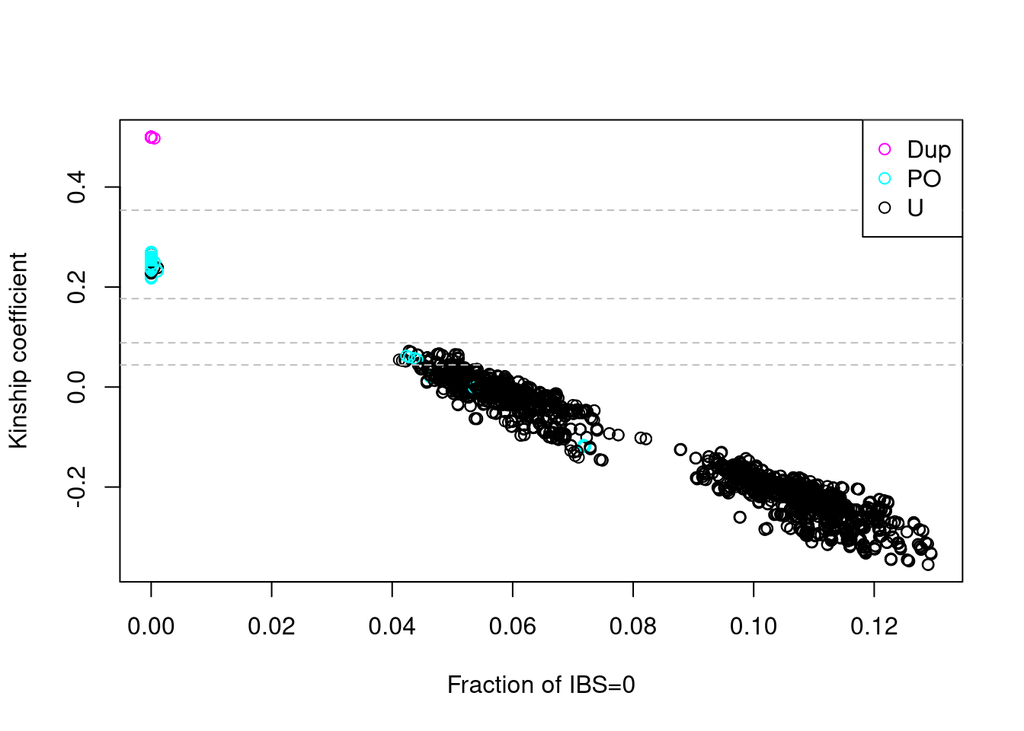

```r
# Finally, plot KC vs IBS0

# Draw horizontal thresholds for assigning relationships using kinship
# coefficients (taken from table 1 of Manichaikul (2010))
cut.dup <- 1 / (2 ^ (3 / 2))
cut.deg1 <- 1 / (2 ^ (5 / 2))
cut.deg2 <- 1 / (2 ^ (7 / 2))
cut.deg3 <- 1 / (2 ^ (9 / 2))
cols <- c(Dup = "magenta",
          PO = "cyan",
          U = "black")
plot(ibd$IBS0,
     ibd$kinship,
     col = cols[ibd$exp.rel],
     xlab = "Fraction of IBS=0",
     ylab = "Kinship coefficient")
abline(
  h = c(cut.deg1, cut.deg2, cut.deg3, cut.dup),
  lty = 2,
  col = "gray"
)
legend("topright",
       legend = names(cols),
       col = cols,
       pch = 1)
```

From the kinship plot, we see there are some inconsistencies between the expected and observed genetic relatedness statistics. Making a table of expected vs. observed relationships can summarize this. Taking “Deg3” and “U” (“Unrelated”) as synonynmous here for simplicity, we would expect all the off-diagonal entries of the table below to be 0.

What we actually see is that 16 pairs that are supposedly unrelated are actually parent-offspring pairs; and 17 pairs that are supposedly parent-offspring pairs are showing up as genetically unrelated. Note that since there are multiple scans per person, there are a lot of relationships pairs here (77 scans implies 77 * 76 / 2 = 2926 possible pairs, which is the sum of the entries in the table). Each of the 33 discrepancies is a ‘dot’ in the ‘wrong cluster’ in the IBD plot we drew.

Can we account for these discrepancies somehow? Let’s try to find the pairs of individuals/families with discrepancies. We see below that only 3 families are involved (families 1344, 1334, and 58). After poring over the list of discrepancies, we also see that they can be disentangled somewhat. The discrepancy involving family 58 concerns only 2 scanIDs, 355 and 356 (both in the same family), so we can tackle it first. (On the other hand, the remaining 32 discrepancies involving families 1344 and 1334 seem more complex.) It appears the discrepancy is due to a case of non-paternity - the pedigree in scanAnnot says that 356 is 355’s father, but the kinship calculation says they’re genetically unrelated. Therefore we should change the family IDs to reflect that they’re unrelated.

```r
#   Make a table of obsereved and expected relationships for each pair of scans
ibd_recoded <- ibd
ibd_recoded$obs.rel[ibd_recoded$obs.rel == "Deg3"] <- "U"
table(expected = ibd_recoded$exp.rel, observed = ibd_recoded$obs.rel)
```

```
##         observed
## expected  Dup   PO    U
##      Dup   34    0    0
##      PO     0   74   17
##      U      0   16 2785
```

```r
#   What are the pairs with discrepancies?

#   Print out all 33 rows
discrepancies <-
  ibd_recoded[!ibd_recoded$exp.rel == ibd_recoded$obs.rel, ]
discrepancies
```

```
##                       ii ID2 ID1         IBS0       kinship  Individ1  Individ2
## 237  200005043/200016815 320 296 0.0463300364  0.0194690265 200016815 200005043
## 238  200005043/200016815 319 296 0.0463059313  0.0207231041 200016815 200005043
## 239  200005043/200016815 320 297 0.0464509395  0.0186500888 200016815 200005043
## 240  200005043/200016815 319 297 0.0464267084  0.0199115044 200016815 200005043
## 293  200005043/200071490 320 298 0.0000000000  0.2664141414 200071490 200005043
## 294  200005043/200071490 319 298 0.0000000000  0.2668350168 200071490 200005043
## 295  200005043/200071490 319 299 0.0000000000  0.2668918919 200071490 200005043
## 296  200005043/200071490 320 299 0.0000000000  0.2664695946 200071490 200005043
## 725  200016815/200019634 323 297 0.0005211047  0.2389575972 200016815 200019634
## 726  200016815/200019634 323 296 0.0005197505  0.2394366197 200016815 200019634
## 727  200016815/200019634 324 297 0.0010695187  0.2381602914 200016815 200019634
## 728  200016815/200019634 324 296 0.0010666667  0.2386775362 200016815 200019634
## 807  200016815/200116780 318 297 0.0719499479 -0.1175595238 200016815 200116780
## 808  200016815/200116780 317 296 0.0718002081 -0.1178217822 200016815 200116780
```

[output cut: 53 more lines]

```r
#   Note that this table includes the scanIDs of each pair involved in a
#   discrepancy

### Which *families* are involved?

#   Get the individual scanIDs first and match them back to the family IDs
discrepancy_ids <- unlist(discrepancies[, c("ID1", "ID2")])
discrepany_fids <-
  pData(scanAnnot)$family[pData(scanAnnot)$scanID %in% discrepancy_ids]
discrepany_fids <- unique(discrepany_fids)
discrepany_fids
```

```
## [1] 1344 1334   58
```

```r
#   The discrepancy with individuals 355 and 356 from family 58 seems easiest to
#   fix first - it only involves one family
discrepancies[discrepancies$ID1  %in% c(355, 356) |
                discrepancies$ID2  %in% c(355, 356) ,]
```

```
##                       ii ID2 ID1       IBS0       kinship  Individ1  Individ2
## 2725 200105428/200122151 356 355 0.05359001 -0.0009057971 200122151 200105428
##      exp.rel obs.rel
## 2725      PO       U
```

```r
pData(scanAnnot)[pData(scanAnnot)$family == "58", ]
```

```
##    scanID subjectID family    father mother CoriellID race sex status
## 76    355 200122151     58 200105428      0   NA19222  YRI   F      0
## 77    356 200105428     58         0      0   NA19223  YRI   M      1
##                                 genoRunID          plate batch
## 76 WG1001000-DNAC07-CIDR_19222@1007850419 WG0061293-AMP2     A
## 77 WG1001000-DNAD10-CIDR_19223@1007850148 WG0061294-AMP2     A
##                       file   missing.e1   missing.e2     het.A       het.X
## 76 GENEVA_1M_HapMap_67.csv 0.0009655616 0.0009655616 0.2843531 0.296842105
## 77 GENEVA_1M_HapMap_65.csv 0.0022229279 0.0022229279 0.2918132 0.001052632
```

```r
#   Since 355 and 356 are actually unrelated, we should give one of them a new
#   family ID

#   Notice we use subjectID here

#   Set "daughter"'s father-ID to 0
pData(scanAnnot)[pData(scanAnnot)$subjectID == 200122151, "father"] <-
  "0"

#   Give the "dad" a new, unique family-ID
pData(scanAnnot)[pData(scanAnnot)$subjectID == 200105428, "family"] <-
  "58-2"
pData(scanAnnot)[pData(scanAnnot)$family == 58, ]
```

```
##    scanID subjectID family father mother CoriellID race sex status
## 76    355 200122151     58      0      0   NA19222  YRI   F      0
##                                 genoRunID          plate batch
## 76 WG1001000-DNAC07-CIDR_19222@1007850419 WG0061293-AMP2     A
##                       file   missing.e1   missing.e2     het.A     het.X
## 76 GENEVA_1M_HapMap_67.csv 0.0009655616 0.0009655616 0.2843531 0.2968421
```

```r
pData(scanAnnot)[pData(scanAnnot)$family == "58-2", ]
```

```
##    scanID subjectID family father mother CoriellID race sex status
## 77    356 200105428   58-2      0      0   NA19223  YRI   M      1
##                                 genoRunID          plate batch
## 77 WG1001000-DNAD10-CIDR_19223@1007850148 WG0061294-AMP2     A
##                       file  missing.e1  missing.e2     het.A       het.X
## 77 GENEVA_1M_HapMap_65.csv 0.002222928 0.002222928 0.2918132 0.001052632
```

Now, you should account for the remaining discrepancies, which simply involve a sample swap between families 1334 and 1344. The sample swap involves just the children from two trios (each is scanned twice, and the parents are all scanned twice).

For the swapped samples, manually “fix” their family IDs, mother IDs, and father IDs in scanAnnot (i.e., swap these IDs back so that each child has the correct parental and family IDs). You only need to adjust the variables `family`, `father`, and `mother` for 4 scans from the 2 children. One of these has completed for you. **Add your code in the next chunk, where indicated.**

```r
### Fixes

#   Print out the pedigree info before and after the "fix"

#   Need to update family, father, and mother for scanIDs 296, 297, 298, and 299

#   296 is done for you

#   Fill in the NAs with the correct values!

# pData(scanAnnot)[pData(scanAnnot)$family == 1334, ]
# pData(scanAnnot)[pData(scanAnnot)$family == 1344, ]

pData(scanAnnot) %>%
  filter(scanID >= 296 & scanID <= 299)
```

```
##   scanID subjectID family    father    mother CoriellID race sex status
## 1    296 200016815   1344 200116780 200005043   NA10846  CEU   M      0
## 2    297 200016815   1344 200116780 200005043   NA10846  CEU   M      0
## 3    298 200071490   1334 200118596 200019634   NA10851  CEU   M      0
## 4    299 200071490   1334 200118596 200019634   NA10851  CEU   M      0
##                                genoRunID          plate batch
## 1 WG1001172-DNAH05-CIDR_10846@1007850610 WG0063165-AMP2     C
## 2 WG1000991-DNAH04-CIDR_10846@1007850376 WG0058565-AMP2     B
## 3 WG1000972-DNAB01-CIDR_10851@1007850566 WG0060472-AMP2     B
## 4 WG1000971-DNAA01-CIDR_10851@1007850374 WG0061537-AMP2     C
##                      file  missing.e1  missing.e2     het.A       het.X
## 1 GENEVA_1M_HapMap_77.csv 0.003810734 0.003810734 0.2903226 0.000000000
## 2 GENEVA_1M_HapMap_27.csv 0.007303906 0.007303906 0.2905508 0.001057082
## 3  GENEVA_1M_HapMap_8.csv 0.002222928 0.002222928 0.3028629 0.000000000
## 4  GENEVA_1M_HapMap_6.csv 0.013655129 0.013655129 0.3018584 0.000000000
```

```r
# Scan1 from Kid 1
pData(scanAnnot)[pData(scanAnnot)$scanID == 296, c("family", "father", "mother")] <-
  c(1334, 200118596, 200019634)

# Scan2 from Kid 1
pData(scanAnnot)[pData(scanAnnot)$scanID == 297, c("family", "father", "mother")] <-
  c(1334, 200118596, 200019634)

# Scan1 from Kid 2
pData(scanAnnot)[pData(scanAnnot)$scanID == 298, c("family", "father", "mother")] <-
  c(1344, 200116780, 200005043)

# Scan2 from Kid 2
pData(scanAnnot)[pData(scanAnnot)$scanID == 299, c("family", "father", "mother")] <-
  c(1344, 200116780, 200005043)

pData(scanAnnot) %>%
  filter(scanID >= 296 & scanID <= 299)
```

```
##   scanID subjectID family    father    mother CoriellID race sex status
## 1    296 200016815   1334 200118596 200019634   NA10846  CEU   M      0
## 2    297 200016815   1334 200118596 200019634   NA10846  CEU   M      0
## 3    298 200071490   1344 200116780 200005043   NA10851  CEU   M      0
## 4    299 200071490   1344 200116780 200005043   NA10851  CEU   M      0
##                                genoRunID          plate batch
## 1 WG1001172-DNAH05-CIDR_10846@1007850610 WG0063165-AMP2     C
## 2 WG1000991-DNAH04-CIDR_10846@1007850376 WG0058565-AMP2     B
## 3 WG1000972-DNAB01-CIDR_10851@1007850566 WG0060472-AMP2     B
## 4 WG1000971-DNAA01-CIDR_10851@1007850374 WG0061537-AMP2     C
##                      file  missing.e1  missing.e2     het.A       het.X
## 1 GENEVA_1M_HapMap_77.csv 0.003810734 0.003810734 0.2903226 0.000000000
## 2 GENEVA_1M_HapMap_27.csv 0.007303906 0.007303906 0.2905508 0.001057082
## 3  GENEVA_1M_HapMap_8.csv 0.002222928 0.002222928 0.3028629 0.000000000
## 4  GENEVA_1M_HapMap_6.csv 0.013655129 0.013655129 0.3018584 0.000000000
```

```r
# pData(scanAnnot)[pData(scanAnnot)$family == 1334, ]
# pData(scanAnnot)[pData(scanAnnot)$family == 1344, ]
```

Now that we’ve “corrected” the sample-swaps, we should make a new IBD plot to verify that observed and expected relationships now match.

```r
#   Recalculate the relatedness as above
# showfile.gds(closeall = TRUE) # close all files otherside gdsobj wouldn't run?
  # source https://github.com/zhengxwen/gdsfmt/issues/17#issuecomment-346899023

gds_geno <-
  system.file("extdata", "illumina_geno.gds", package = "GWASdata")
snps_to_include_for_kinship <-
  snpAnnot$snpID[snpAnnot$missing.n1 < 0.05]
gdsobj <- snpgdsOpen(gds_geno) # this wouldn't run without closing everything first
ibdobj <- snpgdsIBDKING(gdsobj, snp.id = snps_to_include_for_kinship)
```

```
## IBD analysis (KING method of moment) on genotypes:
## Excluding 1,339 SNPs (non-autosomes or non-selection)
## Excluding 35 SNPs (monomorphic: TRUE, MAF: NaN, missing rate: NaN)
##     # of samples: 77
##     # of SNPs: 1,926
##     using 1 thread
## No family is specified, and all individuals are treated as singletons.
## Relationship inference in the presence of population stratification.
## KING IBD:    the sum of all selected genotypes (0,1,2) = 132998
## CPU capabilities: Double-Precision SSE2
## Thu Feb  5 00:06:43 2026    (internal increment: 65536)
## [..................................................]  0%, ETC: ---        [==================================================] 100%, completed, 0s
## Thu Feb  5 00:06:43 2026    Done.
```

```r
snpgdsClose(gdsobj)

#   Re-draw the pedigree
ped <-
  pData(scanAnnot)[, c("family", "subjectID", "father", "mother", "sex")]
dim(ped)
```

```
## [1] 77  5
```

```r
names(ped) <- c("family", "individ", "father", "mother", "sex")
head(ped)
```

```
##   family   individ    father    mother sex
## 1   1341 200191449         0         0   F
## 2   1341 200191449         0         0   F
## 3   1341 200030290 200099417 200191449   F
## 4   1341 200030290 200099417 200191449   F
## 5   1341 200099417         0         0   M
## 6   1341 200099417         0         0   M
```

```r
chk <- pedigreeCheck(ped)
```

```
## All row numbers refer to row in the full pedigree (not just within family).
##  Correct current problems and rerun pedigreeCheck.
## There may be additional problems not investigated because of the current problems.
```

```r
chk
```

```
## $duplicates
##    family   individ copies match
## 1    1341 200191449      2  TRUE
## 2    1341 200030290      2  TRUE
## 3    1341 200099417      2  TRUE
## 4    1341 200015835      2  TRUE
## 5    1340 200099636      2  TRUE
## 6    1340 200076256      2  TRUE
## 7    1408 200074814      2  TRUE
## 8    1408 200094287      2  TRUE
## 9    1408 200019401      2  TRUE
## 10   1334 200016815      2  TRUE
## 11   1334 200118596      2  TRUE
## 12   1334 200019634      2  TRUE
## 13   1344 200071490      2  TRUE
```

[output cut: 31 more lines]

```r
#   Remove duplicates, as before
dups <- chk$duplicates
head(dups)
```

```
##   family   individ copies match
## 1   1341 200191449      2  TRUE
## 2   1341 200030290      2  TRUE
## 3   1341 200099417      2  TRUE
## 4   1341 200015835      2  TRUE
## 5   1340 200099636      2  TRUE
## 6   1340 200076256      2  TRUE
```

```r
uni.ped <- pedigreeDeleteDuplicates(ped, dups)
dim(uni.ped)
```

```
## [1] 43  5
```

```r
chk <- pedigreeCheck(uni.ped)
```

```
## All row numbers refer to row in the full pedigree (not just within family).
##  Correct current problems and rerun pedigreeCheck.
## There may be additional problems not investigated because of the current problems.
```

```r
chk
```

```
## $parent.no.individ.entry
##   row.num family no_individ_entry  parentID
## 1       8   1341           mother 200039107
##
## $one.person.fams
##   family founder
## 1     58    TRUE
## 2   58-2    TRUE
##
## $subfamilies.ident
##   family subfamily   individ
## 1   1362         1 200003297
## 2   1362         1 200169440
## 3   1362         1 200187448
## 6   1362         2 200018192
## 4   1362         2 200024383
## 5   1362         2 200118709
```

```r
#   Recall there was a person whose mother needed to be added to the pedigree

ni <- chk$parent.no.individ.entry
ni
```

```
##   row.num family no_individ_entry  parentID
## 1       8   1341           mother 200039107
```

```r
parent <-
  data.frame(
    family = ni$family,
    individ = ni$parentID,
    father = 0,
    mother = 0,
    sex = "F",
    stringsAsFactors = FALSE
  )
ped.updated <- rbind(uni.ped, parent)
chk <- pedigreeCheck(ped.updated)
```

```
## All row numbers refer to row in the full pedigree (not just within family).
##  Correct current problems and rerun pedigreeCheck.
## There may be additional problems not investigated because of the current problems.
```

```r
chk
```

```
## $one.person.fams
##   family founder
## 1     58    TRUE
## 2   58-2    TRUE
##
## $subfamilies.ident
##    family subfamily   individ
## 2    1341         1 200030290
## 3    1341         1 200099417
## 1    1341         1 200191449
## 5    1341         2 200015835
## 6    1341         2 200039107
## 4    1341         2 200122600
## 7    1362         1 200003297
## 8    1362         1 200169440
## 9    1362         1 200187448
## 12   1362         2 200018192
## 10   1362         2 200024383
## 11   1362         2 200118709
```

```r
#   Recall that a family had to be broken into two new sub-families

ped.complete <- ped.updated
chk <- pedigreeCheck(ped.complete)
```

```
## All row numbers refer to row in the full pedigree (not just within family).
##  Correct current problems and rerun pedigreeCheck.
## There may be additional problems not investigated because of the current problems.
```

```r
subf <- chk$subfamilies.ident
subf
```

```
##    family subfamily   individ
## 2    1341         1 200030290
## 3    1341         1 200099417
## 1    1341         1 200191449
## 5    1341         2 200015835
## 6    1341         2 200039107
## 4    1341         2 200122600
## 7    1362         1 200003297
## 8    1362         1 200169440
## 9    1362         1 200187448
## 12   1362         2 200018192
## 10   1362         2 200024383
## 11   1362         2 200118709
```

```r
table(subf$family)
```

```
##
## 1341 1362
##    6    6
```

```r
subf.ids <- subf$individ[subf$subfamily == 2]
newfam <- ped.complete$individ %in% subf.ids
ped.complete$family[newfam] <-
  paste0(ped.complete$family[newfam], "-2")
table(ped.complete$family)
```

```
##
##     12   1334   1340   1341 1341-2   1344   1347   1362 1362-2   1408     28
##      3      3      3      3      3      3      3      3      3      3      3
##      4      5     58   58-2      9
##      3      3      1      1      3
```

```r
pedigreeCheck(ped.complete)
```

```
## All row numbers refer to row in the full pedigree (not just within family).
##  Correct current problems and rerun pedigreeCheck.
## There may be additional problems not investigated because of the current problems.
```

```
## $one.person.fams
##   family founder
## 1     58    TRUE
## 2   58-2    TRUE
```

```r
chk <- pedigreeCheck(ped.complete)
```

```
## All row numbers refer to row in the full pedigree (not just within family).
##  Correct current problems and rerun pedigreeCheck.
## There may be additional problems not investigated because of the current problems.
```

```r
chk
```

```
## $one.person.fams
##   family founder
## 1     58    TRUE
## 2   58-2    TRUE
```

```r
#   Earlier we split family 58 into two singleton families (the "father" and
#   "daughter" who weren't actually related) pedigreeCheck doesn't like
#   singletons, so we need to assign dummy parents for the original two members
#   of family 58 And these 4 dummy parents need to be added into the pedigree

onefams <- chk$one.person.fams
onefams
```

```
##   family founder
## 1     58    TRUE
## 2   58-2    TRUE
```

```r
ped.complete[ped.complete$family %in% c("58", "58-2"), ]
```

```
##    family   individ father mother sex
## 76     58 200122151      0      0   F
## 77   58-2 200105428      0      0   M
```

```r
ped.complete[ped.complete$family == "58",  c("father", "mother")] <-
  c("1111", "2222")
ped.complete[ped.complete$family == "58-2", c("father", "mother")] <-
  c("3333", "4444")

parents <- data.frame(
  family = c("58", "58", "58-2", "58-2"),
  individ = c("1111", "2222", "3333", "4444"),
  father = c(0, 0, 0, 0),
  mother = c(0, 0, 0, 0),
  sex = c("M", "F", "M", "F"),
  stringsAsFactors = FALSE
)

#   Complete the final pedigree, and now pedigreeCheck is happy (it returns NULL)

ped.final <- rbind(ped.complete, parents)
pedigreeCheck(ped.final)
```

```r
# Recalculate expected relationships in order to make a new plot, as above

ped.complete <- ped.final
rels <- pedigreePairwiseRelatedness(ped.final)
length(rels$inbred.fam)
```

```
## [1] 0
```

```r
relprs <- rels$relativeprs
relprs[1:5, ]
```

```
##    Individ1  Individ2 relation kinship family
## 1 200191449 200030290       PO    0.25   1341
## 2 200191449 200099417        U    0.00   1341
## 3 200030290 200099417       PO    0.25   1341
## 4 200099636 200032162        U    0.00   1340
## 5 200099636 200076256       PO    0.25   1340
```

```r
table(relprs$relation)
```

```
##
## PO  U
## 32 16
```

```r
samp <- pData(scanAnnot)[, c("scanID", "subjectID")]
samp <- samp[match(ibdobj$sample.id, samp$scanID), ]
names(samp) <- c("scanID", "Individ")
ibd <- snpgdsIBDSelection(ibdobj)
ibd <- merge(ibd, samp, by.x = "ID1", by.y = "scanID")
ibd <-
  merge(
    ibd,
    samp,
    by.x = "ID2",
    by.y = "scanID",
    suffixes = c("1", "2")
  )
ibd$ii <- pasteSorted(ibd$Individ1, ibd$Individ2)
relprs$ii <- pasteSorted(relprs$Individ1, relprs$Individ2)
ibd <- merge(ibd, relprs[, c("ii", "relation")], all.x = TRUE)
names(ibd)[names(ibd) == "relation"] <- "exp.rel"
ibd$exp.rel[ibd$Individ1 == ibd$Individ2] <- "Dup"
ibd$exp.rel[is.na(ibd$exp.rel)] <- "U"
table(ibd$exp.rel, useNA = "ifany")
```

```
##
##  Dup   PO    U
##   34   90 2802
```

```r
#   Use the ibdAssignRelatednessKing function to call the observed relationships
#   based on IBS0 and kinship values for each pair

ibd$obs.rel <- ibdAssignRelatednessKing(ibd$IBS0, ibd$kinship)
table(ibd$obs.rel, useNA = "ifany")
```

```
##
## Deg3  Dup   PO    U
##   64   34   90 2738
```

```r
#   Observe that now the observed and expected relationships match (if we take
#   Deg3 and Unrelated as synonymous)

table(ibd$exp.rel, ibd$obs.rel)
```

```
##
##       Deg3  Dup   PO    U
##   Dup    0   34    0    0
##   PO     0    0   90    0
##   U     64    0    0 2738
```

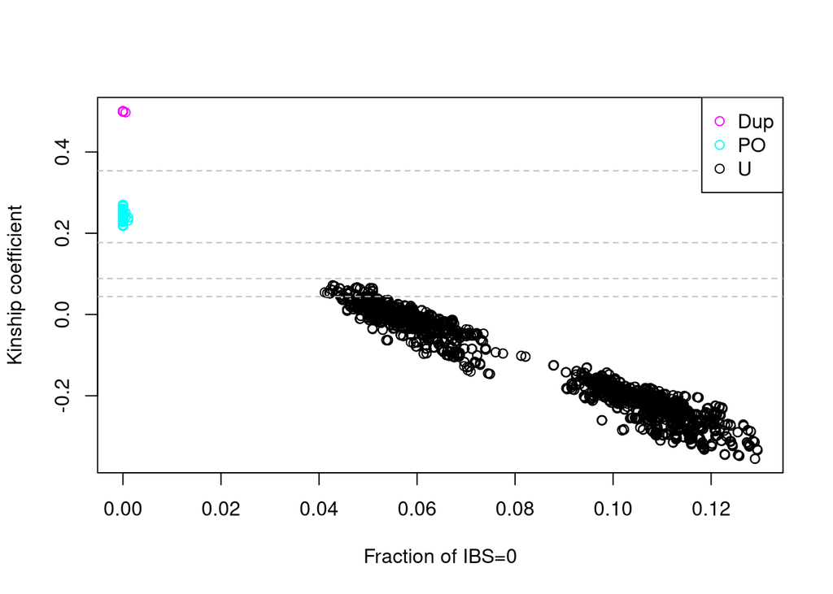

```r
#   Finally, plot KC vs IBS0

#   Draw horizontal hresholds for assigning relationships using kinship
#   coefficients (taken from table 1 of Manichaikul (2010))

#   Now none of  the dots appear to be in the "wrong" clusters

cut.dup <- 1 / (2 ^ (3 / 2))
cut.deg1 <- 1 / (2 ^ (5 / 2))
cut.deg2 <- 1 / (2 ^ (7 / 2))
cut.deg3 <- 1 / (2 ^ (9 / 2))
cols <- c(Dup = "magenta",
          PO = "cyan",
          U = "black")
plot(ibd$IBS0,
     ibd$kinship,
     col = cols[ibd$exp.rel],
     xlab = "Fraction of IBS=0",
     ylab = "Kinship coefficient")
abline(
  h = c(cut.deg1, cut.deg2, cut.deg3, cut.dup),
  lty = 2,
  col = "gray"
)
legend("topright",
       legend = names(cols),
       col = cols,
       pch = 1)
```

## Part 4 - Report (Relatedness)

- Summarize the pedigree structures you observe in the data.
  - There appears to be 34 duplicate pairs and 90 parent-offspring pairs, and most of the data (2802 points) is a large cluster of unrelated pairs.
- Describe what discrepancies you observe in the initial kinship vs IBS0 plot.
  - Initially, there were several parent-offspring pairs located in the “unrelated” cluster and unrelated pairs located in the “parent-offspring” cluster.
- Explain exactly the kinds of swaps/discrepancies that were found, which IDs were involved, and exactly how you “fixed” them.
  - It turns out there were four sample swaps (two subjects) for scanIDs 296 and 297 (from subjectID 200016815), 298 and 299 (from subjectID 200071490). This was corrected simply by manually swapping the mother, father, and family IDs from these two subjects.  
    There was also a discrepancy where the scanAnnot pedigree said that scanID 356 is 355’s father, but according to the kinship calculation they are genetically unrelated. We corrected this by setting scanID 355’s father to 0 and giving scanID 356 a new unique family ID (58_2 instead of 58).
- How would you recommend following up on these discrepancies “in real life” (instead of just assuming we know what happened and manually changing the data, which is a *bad idea*)?
  - I would alert my PI of this first and see what they would like us to do. I would also ask the lab tech to see if it was an error on their end, and drop the sample if I was truly uncertain.
- Add a column to scanAnnot called “relationship.changes”, which briefly summarizes these “fixes” (add metadata for the column, too).

```r
#   <Your code goes here>
# Summarize the pedigree structures you observe in the data.
table(ibd$exp.rel)
```

```
##
##  Dup   PO    U
##   34   90 2802
```

```r
# Add a column to scanAnnot called "relationship.changes", which briefly summarizes these "fixes" (add metadata for the column, too).
scanAnnot$relationship.changes <- NA
  # if scanID = 296, 297, 298, 299, 356, 355, value is something else

s <- pData(scanAnnot)
s$relationship.changes <- NA
s <- s %>%
    mutate(relationship.changes = case_when(
      scanID >= 296 & scanID <= 299 ~ "sample_swap",
      scanID == 356 | scanID == 355 ~ "unrelated",
    ))
head(s)
```

```
##   scanID subjectID family    father    mother CoriellID race sex status
## 1    280 200191449   1341         0         0   NA06985  CEU   F      1
## 2    281 200191449   1341         0         0   NA06985  CEU   F      1
## 3    282 200030290   1341 200099417 200191449   NA06991  CEU   F      0
## 4    283 200030290   1341 200099417 200191449   NA06991  CEU   F      0
## 5    284 200099417   1341         0         0   NA06993  CEU   M      1
## 6    285 200099417   1341         0         0   NA06993  CEU   M      1
##                                genoRunID          plate batch
## 1 WG1000993-DNAG10-CIDR_06985@1007850397 WG0052814-AMP2     A
## 2 WG1000992-DNAF10-CIDR_06985@1007850586 WG0061258-AMP2     A
## 3 WG1000970-DNAB11-CIDR_06991@1007850444 WG0061536-AMP2     B
## 4 WG1000969-DNAA11-CIDR_06991@1007850587 WG0053489-AMP2     A
## 5 WG1000972-DNAE10-CIDR_06993@1007850591 WG0060475-AMP2     C
## 6 WG1000971-DNAD10-CIDR_06993@1007850421 WG0061540-AMP2     B
##                      file  missing.e1  missing.e2     het.A     het.X
## 1 GENEVA_1M_HapMap_37.csv 0.001931123 0.001931123 0.2968358 0.3147368
## 2 GENEVA_1M_HapMap_58.csv 0.004184100 0.004184100 0.2961847 0.3147368
## 3  GENEVA_1M_HapMap_5.csv 0.004505954 0.004505954 0.2901763 0.2967265
## 4  GENEVA_1M_HapMap_3.csv 0.011264886 0.011264886 0.2900955 0.2956705
## 5 GENEVA_1M_HapMap_10.csv 0.001587806 0.001587806 0.2895133 0.0000000
## 6 GENEVA_1M_HapMap_71.csv 0.003493172 0.003493172 0.2890782 0.0000000
##   relationship.changes
## 1                 <NA>
## 2                 <NA>
## 3                 <NA>
## 4                 <NA>
## 5                 <NA>
## 6                 <NA>
```

```r
# turn this back into a SnpAnnotationDataFrame called scanAnnot
scanAnnot <- ScanAnnotationDataFrame(s)

varMetadata(scanAnnot)["relationship.changes", "labelDescription"] <- "relationship fixes"

pData(scanAnnot) %>%
  filter(scanID >= 296 & scanID <= 299)
```

```
##   scanID subjectID family    father    mother CoriellID race sex status
## 1    296 200016815   1334 200118596 200019634   NA10846  CEU   M      0
## 2    297 200016815   1334 200118596 200019634   NA10846  CEU   M      0
## 3    298 200071490   1344 200116780 200005043   NA10851  CEU   M      0
## 4    299 200071490   1344 200116780 200005043   NA10851  CEU   M      0
##                                genoRunID          plate batch
## 1 WG1001172-DNAH05-CIDR_10846@1007850610 WG0063165-AMP2     C
## 2 WG1000991-DNAH04-CIDR_10846@1007850376 WG0058565-AMP2     B
## 3 WG1000972-DNAB01-CIDR_10851@1007850566 WG0060472-AMP2     B
## 4 WG1000971-DNAA01-CIDR_10851@1007850374 WG0061537-AMP2     C
##                      file  missing.e1  missing.e2     het.A       het.X
## 1 GENEVA_1M_HapMap_77.csv 0.003810734 0.003810734 0.2903226 0.000000000
## 2 GENEVA_1M_HapMap_27.csv 0.007303906 0.007303906 0.2905508 0.001057082
## 3  GENEVA_1M_HapMap_8.csv 0.002222928 0.002222928 0.3028629 0.000000000
## 4  GENEVA_1M_HapMap_6.csv 0.013655129 0.013655129 0.3018584 0.000000000
##   relationship.changes
## 1          sample_swap
## 2          sample_swap
## 3          sample_swap
## 4          sample_swap
```

```r
pData(scanAnnot) %>%
  filter(scanID >= 355 & scanID <= 356)
```

```
##   scanID subjectID family father mother CoriellID race sex status
## 1    355 200122151     58      0      0   NA19222  YRI   F      0
## 2    356 200105428   58-2      0      0   NA19223  YRI   M      1
##                                genoRunID          plate batch
## 1 WG1001000-DNAC07-CIDR_19222@1007850419 WG0061293-AMP2     A
## 2 WG1001000-DNAD10-CIDR_19223@1007850148 WG0061294-AMP2     A
##                      file   missing.e1   missing.e2     het.A       het.X
## 1 GENEVA_1M_HapMap_67.csv 0.0009655616 0.0009655616 0.2843531 0.296842105
## 2 GENEVA_1M_HapMap_65.csv 0.0022229279 0.0022229279 0.2918132 0.001052632
##   relationship.changes
## 1            unrelated
## 2            unrelated
```

```r
head(pData(scanAnnot))
```

```
##   scanID subjectID family    father    mother CoriellID race sex status
## 1    280 200191449   1341         0         0   NA06985  CEU   F      1
## 2    281 200191449   1341         0         0   NA06985  CEU   F      1
## 3    282 200030290   1341 200099417 200191449   NA06991  CEU   F      0
## 4    283 200030290   1341 200099417 200191449   NA06991  CEU   F      0
## 5    284 200099417   1341         0         0   NA06993  CEU   M      1
## 6    285 200099417   1341         0         0   NA06993  CEU   M      1
##                                genoRunID          plate batch
## 1 WG1000993-DNAG10-CIDR_06985@1007850397 WG0052814-AMP2     A
## 2 WG1000992-DNAF10-CIDR_06985@1007850586 WG0061258-AMP2     A
## 3 WG1000970-DNAB11-CIDR_06991@1007850444 WG0061536-AMP2     B
## 4 WG1000969-DNAA11-CIDR_06991@1007850587 WG0053489-AMP2     A
## 5 WG1000972-DNAE10-CIDR_06993@1007850591 WG0060475-AMP2     C
## 6 WG1000971-DNAD10-CIDR_06993@1007850421 WG0061540-AMP2     B
##                      file  missing.e1  missing.e2     het.A     het.X
## 1 GENEVA_1M_HapMap_37.csv 0.001931123 0.001931123 0.2968358 0.3147368
## 2 GENEVA_1M_HapMap_58.csv 0.004184100 0.004184100 0.2961847 0.3147368
## 3  GENEVA_1M_HapMap_5.csv 0.004505954 0.004505954 0.2901763 0.2967265
## 4  GENEVA_1M_HapMap_3.csv 0.011264886 0.011264886 0.2900955 0.2956705
## 5 GENEVA_1M_HapMap_10.csv 0.001587806 0.001587806 0.2895133 0.0000000
## 6 GENEVA_1M_HapMap_71.csv 0.003493172 0.003493172 0.2890782 0.0000000
##   relationship.changes
## 1                 <NA>
## 2                 <NA>
## 3                 <NA>
## 4                 <NA>
## 5                 <NA>
## 6                 <NA>
```

```r
varMetadata(scanAnnot)
```

```
##                        labelDescription
## scanID                             <NA>
## subjectID                          <NA>
## family                             <NA>
## father                             <NA>
## mother                             <NA>
## CoriellID                          <NA>
## race                               <NA>
## sex                                <NA>
## status                             <NA>
## genoRunID                          <NA>
## plate                              <NA>
## batch                              <NA>
## file                               <NA>
## missing.e1                         <NA>
## missing.e2                         <NA>
## het.A                              <NA>
## het.X                              <NA>
## relationship.changes relationship fixes
```

## Part 5 - Principal component analysis (PCA) and population substructure

Here you’ll be introduced to performing PCA to uncover population substructure.

```r
#   For input when we calculate PCA, we want to exclude SNPs from a few
#   problematic loci

#   Including SNPs from 2q21 (LCT), HLA, 8p23, and 17q21.31 can result PCs that
#   are highly correlated with these SNPs, which is undesirable

#   GWASTools supplies the positions of these loci in the relevant genome build
#   in a data frame called pcaSnpFilters.hg18

#   (Note that these loci are on chromosomes 2, 6, 8, and 17, which aren't
#   included in our genotyping data; we'll proceed in this example as if we had
#   genome-wide SNPs)
filt <- get(data(pcaSnpFilters.hg18))

#   Next we pull out the chromosomes, positions, and IDs of the SNPs in our
#   dataset
chrom <- getChromosome(snpAnnot)
pos <- getPosition(snpAnnot)
snpID <- getSnpID(snpAnnot)
snp.filt <- rep(TRUE, length(snpID))

#   We loop over the 4 regions to be excluded and identify which of our SNPs lie
#   with the endpoints of each
for (f in 1:nrow(filt)) {
  snp.filt[chrom == filt$chrom[f] &
             filt$start.base[f] < pos & pos < filt$end.base[f]] <- FALSE
}

#   Make a vector called snp.sel containing the snpIDs of SNPs not in the
#   problematic regions; these are the SNPs we'll retain for PCA
snp.sel <- snpID[snp.filt]
length(snp.sel)
```

```
## [1] 3300
```

```r
#   (None of our 3300 SNPs get filtered out in this step, since they're not on
#   chromosomes 2, 6, 8, or 17)


### We also want to filter out some samples before running PCA

### Specifically, we shouldn't include duplicates (for subjects with multiple
### samples, we'll just pick one sample)

#   We'll re-order scanAnnot by missing.e1 so duplicate subjectIDs with a higher
#   missing rate are marked as duplicates

#   It's important that scanAnnot stays in the same order when we're done

#   Before changing the order, verify that scanAnnot is ordered by increasing
#   scanID (it is)
allequal(scanAnnot$scanID, sort(scanAnnot$scanID))
```

```
## [1] TRUE
```

```r
#   Now re-order so that duplicate subjectIDs with a higher missing rate are
#   marked as duplicates
scanAnnot <-
  scanAnnot[order(scanAnnot$subjectID, scanAnnot$missing.e1), ]

#   Add a new column called "duplicated" indicating who the duplicates are
scanAnnot$duplicated <- duplicated(scanAnnot$subjectID)
table(scanAnnot$duplicated, useNA = "ifany")
```

```
##
## FALSE  TRUE
##    43    34
```

```r
#   Put scanAnnot back in scanID order; this is very important!
scanAnnot <- scanAnnot[order(scanAnnot$scanID), ]
allequal(scanAnnot$scanID, sort(scanAnnot$scanID))
```

```
## [1] TRUE
```

```r
#   Update the metadata
varMetadata(scanAnnot)["duplicated", "labelDescription"] <-
  "TRUE for duplicate scan with higher missing.e1"

#   Now make a vector of the scanIDs, leaving out the duplicates with higher
#   missingness (43 remain)
sample.sel <- scanAnnot$scanID[!scanAnnot$duplicated]
length(sample.sel)
```

```
## [1] 43
```

```r
#   Note that in some applications you would only want to include unrelated
#   subjects when calculating PCs

#   In this exploratory example, we'll include parents and their children
#   instead of restricting ourselves to unrelated "founders""


### Now we can perform LD pruning, where independent SNPs are chosen using a
### "sliding window" along the chromosomes

### Re-open the genotypes (after making sure the previous connection is closed)

#close(genoData)
showfile.gds(closeall = T)
```

```
##                                                                                   FileName
## 1 /software/rhel9/manual/install/r/4.5.0/lib64/R/library/GWASdata/extdata/illumina_qxy.gds
## 2  /software/rhel9/manual/install/r/4.5.0/lib64/R/library/GWASdata/extdata/illumina_bl.gds
##   ReadOnly  State
## 1     TRUE closed
## 2     TRUE closed
```

```r
gdsobj <- snpgdsOpen(genofile)

### Use the snpgdsLDpruning function

#   · sample.id/snp.id are used to retain only the samples/SNPs we picked out
#     above
#   · only autosomal SNPs are used
#   · a MAF threshold of 5% is applied
#   · the maximum window size we use is 1 megabase
#   · the LD threshold is set

#   Read the Details section of the help page for snpgdsLDpruning to understand
#   how the pruning algorithm work
snpset <- snpgdsLDpruning(
  gdsobj,
  sample.id = sample.sel,
  snp.id = snp.sel,
  autosome.only = TRUE,
  maf = 0.05,
  missing.rate = 0.05,
  method = "corr",
  slide.max.bp = 10e6,
  ld.threshold = sqrt(0.1)
)
```

```
## SNP pruning based on LD:
## Excluding 1,300 SNPs (non-autosomes or non-selection)
## Excluding 237 SNPs (monomorphic: TRUE, MAF: 0.05, missing rate: 0.05)
##     # of samples: 43
##     # of SNPs: 1,763
##     using 1 thread
##     sliding window: 10,000,000 basepairs, Inf SNPs
##     |LD| threshold: 0.316228
##     method: correlation
## Chrom 21: |====================|====================|
##     8.20%, 82 / 1,000 (Thu Feb  5 00:06:44 2026)
## Chrom 22: |====================|====================|
##     8.90%, 89 / 1,000 (Thu Feb  5 00:06:44 2026)
## 171 markers are selected in total.
```

```r
snp.pruned <- unlist(snpset, use.names = FALSE)
length(snp.pruned)
```

```
## [1] 171
```

```r
#   The output is a list the SNPs on each chromosome

#   (Roughly 180 SNPs are retained. Note that this procedure includes a random
#   process, so the number of SNPs selected will vary)


#   Now we calculate the PCs by applying snpgdsPCA, using only the pruned SNPs
#   and the samples selected earlier
pca <- snpgdsPCA(gdsobj, sample.id = sample.sel, snp.id = snp.pruned)
```

```
## Principal Component Analysis (PCA) on genotypes:
## Excluding 3,129 SNPs (non-autosomes or non-selection)
## Excluding 0 SNP (monomorphic: TRUE, MAF: NaN, missing rate: NaN)
##     # of samples: 43
##     # of SNPs: 171
##     using 1 thread
##     # of principal components: 32
## PCA:    the sum of all selected genotypes (0,1,2) = 6277
## CPU capabilities: Double-Precision SSE2
## Thu Feb  5 00:06:44 2026    (internal increment: 55532)
## [..................................................]  0%, ETC: ---        [==================================================] 100%, completed, 0s
## Thu Feb  5 00:06:44 2026    Begin (eigenvalues and eigenvectors)
## Thu Feb  5 00:06:44 2026    Done.
```

```r
dim(pca$eigenvect)
```

```
## [1] 43 32
```

```r
head(pca$eigenvect)
```

```
##             [,1]          [,2]        [,3]        [,4]        [,5]        [,6]
## [1,] -0.15489013 -8.468712e-02  0.20453494  0.21244405 -0.06682279  0.05632997
## [2,] -0.15735154  1.010279e-01  0.02194414  0.21647384 -0.15870040 -0.08424463
## [3,] -0.12456796  2.664856e-01 -0.13728919  0.07668661 -0.13081125 -0.08072931
## [4,] -0.08706342 -1.204903e-01  0.08193742 -0.06761366 -0.27459703 -0.25753559
## [5,] -0.05348107  8.838472e-05  0.10374890 -0.02913876 -0.01591462 -0.07656197
## [6,] -0.06864728 -1.076400e-01  0.14287235 -0.04197584 -0.15537759 -0.21492998
##             [,7]         [,8]        [,9]       [,10]       [,11]       [,12]
## [1,] -0.10730933 -0.163282580 -0.11960789  0.33032578  0.26246766 -0.06118109
## [2,] -0.15118583 -0.164444368 -0.19342003  0.14885391  0.21593094  0.18223367
## [3,] -0.13421152 -0.001694037 -0.17371102 -0.09565554  0.10901238  0.13311213
## [4,]  0.17647023 -0.122271751 -0.02728906 -0.14989185 -0.09894497 -0.41083338
## [5,] -0.07936068 -0.262892567 -0.17997497 -0.18799805 -0.04344889  0.21437968
## [6,]  0.03425779 -0.319808019 -0.10047201 -0.19345129 -0.14417285 -0.02455939
##             [,13]       [,14]      [,15]       [,16]       [,17]         [,18]
```

[output cut: 27 more lines]

```r
#   The function returns a list of 8 objects, including the eigenvectors and the
#   ordered scanIDs

#   32 eigenvectors/PCs have been provided (in order); they're stored in
#   pca$eigenvect, a 43x32 matrix (43 samples by 32 eigenvectors)
```

## Part 5 - Report

```r
library(GGally) # thank you Caylin Grove for this suggestion!
```

```r
# https://r-charts.com/correlation/ggpairs/

scan <- pData(scanAnnot)
head(scan)
```

```
##   scanID subjectID family    father    mother CoriellID race sex status
## 1    280 200191449   1341         0         0   NA06985  CEU   F      1
## 2    281 200191449   1341         0         0   NA06985  CEU   F      1
## 3    282 200030290   1341 200099417 200191449   NA06991  CEU   F      0
## 4    283 200030290   1341 200099417 200191449   NA06991  CEU   F      0
## 5    284 200099417   1341         0         0   NA06993  CEU   M      1
## 6    285 200099417   1341         0         0   NA06993  CEU   M      1
##                                genoRunID          plate batch
## 1 WG1000993-DNAG10-CIDR_06985@1007850397 WG0052814-AMP2     A
## 2 WG1000992-DNAF10-CIDR_06985@1007850586 WG0061258-AMP2     A
## 3 WG1000970-DNAB11-CIDR_06991@1007850444 WG0061536-AMP2     B
## 4 WG1000969-DNAA11-CIDR_06991@1007850587 WG0053489-AMP2     A
## 5 WG1000972-DNAE10-CIDR_06993@1007850591 WG0060475-AMP2     C
## 6 WG1000971-DNAD10-CIDR_06993@1007850421 WG0061540-AMP2     B
##                      file  missing.e1  missing.e2     het.A     het.X
## 1 GENEVA_1M_HapMap_37.csv 0.001931123 0.001931123 0.2968358 0.3147368
## 2 GENEVA_1M_HapMap_58.csv 0.004184100 0.004184100 0.2961847 0.3147368
## 3  GENEVA_1M_HapMap_5.csv 0.004505954 0.004505954 0.2901763 0.2967265
## 4  GENEVA_1M_HapMap_3.csv 0.011264886 0.011264886 0.2900955 0.2956705
## 5 GENEVA_1M_HapMap_10.csv 0.001587806 0.001587806 0.2895133 0.0000000
## 6 GENEVA_1M_HapMap_71.csv 0.003493172 0.003493172 0.2890782 0.0000000
##   relationship.changes duplicated
## 1                 <NA>      FALSE
## 2                 <NA>       TRUE
## 3                 <NA>      FALSE
## 4                 <NA>       TRUE
## 5                 <NA>      FALSE
## 6                 <NA>       TRUE
```

```r
# Make pairwise scatterplots of the first 4 PCs, using different plotting symbols for the two populations, as reported in the "race" variable in scanAnnot.
# turn eigenvectors into dataframe
pcs <- data.frame(pca$eigenvect) # thank you again Caylin Grove
head(pcs)
```

```
##            X1            X2          X3          X4          X5          X6
## 1 -0.15489013 -8.468712e-02  0.20453494  0.21244405 -0.06682279  0.05632997
## 2 -0.15735154  1.010279e-01  0.02194414  0.21647384 -0.15870040 -0.08424463
## 3 -0.12456796  2.664856e-01 -0.13728919  0.07668661 -0.13081125 -0.08072931
## 4 -0.08706342 -1.204903e-01  0.08193742 -0.06761366 -0.27459703 -0.25753559
## 5 -0.05348107  8.838472e-05  0.10374890 -0.02913876 -0.01591462 -0.07656197
## 6 -0.06864728 -1.076400e-01  0.14287235 -0.04197584 -0.15537759 -0.21492998
##            X7           X8          X9         X10         X11         X12
## 1 -0.10730933 -0.163282580 -0.11960789  0.33032578  0.26246766 -0.06118109
## 2 -0.15118583 -0.164444368 -0.19342003  0.14885391  0.21593094  0.18223367
## 3 -0.13421152 -0.001694037 -0.17371102 -0.09565554  0.10901238  0.13311213
## 4  0.17647023 -0.122271751 -0.02728906 -0.14989185 -0.09894497 -0.41083338
## 5 -0.07936068 -0.262892567 -0.17997497 -0.18799805 -0.04344889  0.21437968
## 6  0.03425779 -0.319808019 -0.10047201 -0.19345129 -0.14417285 -0.02455939
##            X13         X14        X15         X16         X17           X18
```

[output cut: 27 more lines]

```r
# turn sample.ids into dataframe
samples <- data.frame(pca$sample.id)
head(samples)
```

```
##   pca.sample.id
## 1           280
## 2           282
## 3           284
## 4           287
## 5           288
## 6           289
```

```r
# add race column to sample.id dataframe
join <- samples %>%
  left_join(select(scan, scanID, race), join_by(pca.sample.id == scanID))
head(join)
```

```
##   pca.sample.id race
## 1           280  CEU
## 2           282  CEU
## 3           284  CEU
## 4           287  CEU
## 5           288  CEU
## 6           289  CEU
```

```r
dim(join)
```

```
## [1] 43  2
```

```r
dim(pcs)
```

```
## [1] 43 32
```

```r
# merge race + samples with PCs (43 rows each)
pcs2 <- cbind(join, pcs)
head(pcs2)
```

```
##   pca.sample.id race          X1            X2          X3          X4
## 1           280  CEU -0.15489013 -8.468712e-02  0.20453494  0.21244405
## 2           282  CEU -0.15735154  1.010279e-01  0.02194414  0.21647384
## 3           284  CEU -0.12456796  2.664856e-01 -0.13728919  0.07668661
## 4           287  CEU -0.08706342 -1.204903e-01  0.08193742 -0.06761366
## 5           288  CEU -0.05348107  8.838472e-05  0.10374890 -0.02913876
## 6           289  CEU -0.06864728 -1.076400e-01  0.14287235 -0.04197584
##            X5          X6          X7           X8          X9         X10
## 1 -0.06682279  0.05632997 -0.10730933 -0.163282580 -0.11960789  0.33032578
## 2 -0.15870040 -0.08424463 -0.15118583 -0.164444368 -0.19342003  0.14885391
## 3 -0.13081125 -0.08072931 -0.13421152 -0.001694037 -0.17371102 -0.09565554
## 4 -0.27459703 -0.25753559  0.17647023 -0.122271751 -0.02728906 -0.14989185
## 5 -0.01591462 -0.07656197 -0.07936068 -0.262892567 -0.17997497 -0.18799805
## 6 -0.15537759 -0.21492998  0.03425779 -0.319808019 -0.10047201 -0.19345129
##           X11         X12          X13         X14        X15         X16
```

[output cut: 27 more lines]

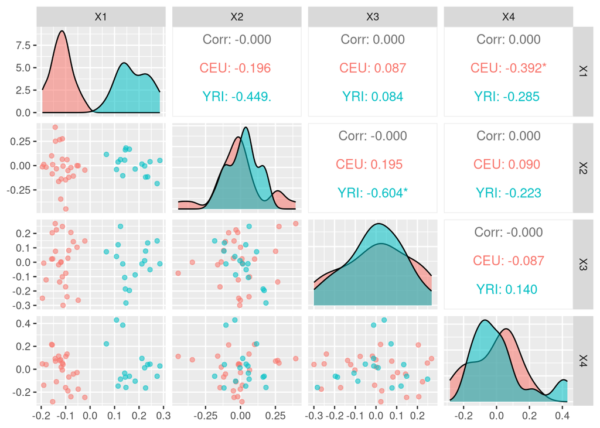

```r
ggpairs(pcs2,
        columns = 3:6,
        aes(color = race, alpha = 0.2))
```

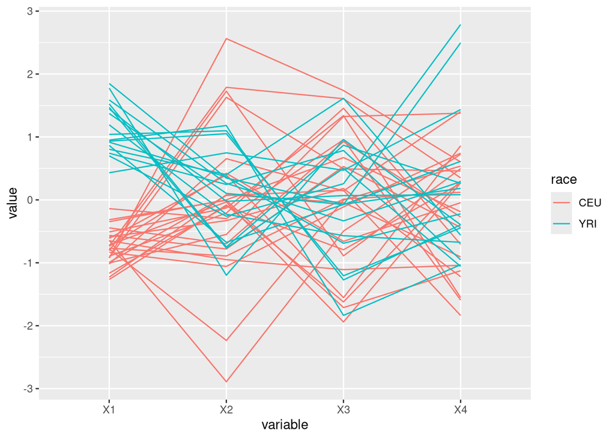

```r
# Make a parallel coordinate plot for the first 4 plots as well, again distinguishing the plotted lines according to the "race" variable.
ggparcoord(pcs2,
           columns = 3:6, groupColumn = 2)
```

## Part 6 - Duplicate Sample Discordance

Here we leverage the duplicate samples to assess genotyping errors. If the same probe often yields different genotypes for duplicate scans from the same subjects, we should probably exclude the genotypes called from that probe. We will use the function `duplicateDiscordance`.

```r
#   First, we should only use high-quality scans to when we judge the probes
scan.excl <- scanAnnot$scanID[scanAnnot$missing.e1 >= 0.05]
length(scan.excl)
```

```
## [1] 0
```

```r
#   (Recall that none of our scans had high missingness, so we don't have to
#   exclude anyone in this dataset)

#   We also don't want to bother testing for discordance in SNPs that are 100%
#   missing, so we exclude those, too
snp.excl <- snpAnnot$snpID[snpAnnot$missing.n1 == 1]
length(snp.excl)
```

```
## [1] 151
```

```r
#   Get the genotype data (make sure the connection to the file is closed before
#   reopening it)

#close(genoData)
showfile.gds(closeall = T, verbose = T)
```

```
##                                                                                    FileName
## 1 /software/rhel9/manual/install/r/4.5.0/lib64/R/library/GWASdata/extdata/illumina_geno.gds
##   ReadOnly  State
## 1     TRUE closed
```

```r
genofile <-
  system.file("extdata", "illumina_geno.gds", package = "GWASdata")
genoGDS <- GdsGenotypeReader(genofile)

#   Attach the annotation to it (note that the sex/relatedness information were
#   "fixed" above)
genoData <-
  GenotypeData(genoGDS, snpAnnot = snpAnnot, scanAnnot = scanAnnot)

#   Now we use the dupdisc function to calculate the discordance for each SNP
#   (while excluding any low-quality scans and 100%-missing SNPs)
dupdisc <-
  duplicateDiscordance(
    genoData,
    subjName.col = "subjectID",
    scan.exclude = scan.excl,
    snp.exclude = snp.excl
  )
```

[output not shown]

[output not shown]

[output not shown]

[output not shown]

[output not shown]

[output not shown]

[output not shown]

[output not shown]

[output not shown]

[output not shown]

[output not shown]

[output not shown]

[output not shown]

[output not shown]

[output not shown]

[output not shown]

[output not shown]

[output not shown]

[output not shown]

[output not shown]

[output not shown]

[output not shown]

[output not shown]

[output not shown]

[output not shown]

[output not shown]

[output not shown]

[output not shown]

[output not shown]

[output not shown]

[output not shown]

[output not shown]

[output not shown]

[output not shown]

```r
#   The function returns a list of 3 objects: discordance.by.snp,
#   discordance.by.subject, and correlation.by.subject
names(dupdisc)
```

```
## [1] "discordance.by.snp"     "discordance.by.subject" "correlation.by.subject"
```

```r
dim(dupdisc$discordance.by.snp)
```

```
## [1] 3149    5
```

```r
head(dupdisc$discordance.by.snp)
```

```
##    snpID discordant npair n.disc.subj discord.rate
## 1 999465          0    33           0            0
## 2 999493          0    31           0            0
## 3 999512          0    34           0            0
## 4 999561          0    34           0            0
## 5 999567          0    34           0            0
## 6 999569          0    34           0            0
```

```r
#   discordance.by.snp has a row for each SNP, detailing the number of
#   duplicate-pairs of scans observed for that SNP, the number of discordant
#   gentoypes observed among those pairs, and the discordance rate
length(dupdisc$discordance.by.subject)
```

```
## [1] 34
```

```r
#   discordance.by.subject is a list of matrices. For each subject with
#   duplicate scans, the matrix shows the discordance between the pairs of scans
#   (i.e., at what proportion of SNPs do two scans from the same person have
#   different genotypes?)
dupdisc$discordance.by.subject[[1]]
```

```
##     280 281
## 280   0   0
## 281   0   0
```

```r
#   For the first subject in dupdisc$discordance.by.subject (scans 280/281), it
#   looks like the genotypes agreed for all the SNPs
dupdisc$discordance.by.subject[[2]]
```

```
##              282          283
## 282 0.0000000000 0.0003265839
## 283 0.0003265839 0.0000000000
```

```r
#   For the second subject (scans 282/283), the discordance rate was
#   0.0003265839

#   Save a summary of this information by merging the discordances into the SNP
#   annotation

snpAnnot$dummy <- 1:nrow(pData(snpAnnot))
pData(snpAnnot) <-
  merge(
    x = pData(snpAnnot),
    y = dupdisc$discordance.by.snp[, c("snpID", "discordant")],
    all.x = T,
    all.y = F
  )

#   Make sure the order of the SNPs is maintained

pData(snpAnnot) <- pData(snpAnnot)[order(snpAnnot$dummy), ]
```